# analysis

2025-01-01

website origin data https://www.kaggle.com/datasets/spscientist/students-performance-in-exams/code

resource of checking normality https://www.sthda.com/english/wiki/normality-test-in-r

resource on linear regression https://www.sthda.com/english/articles/39-regression-model-diagnostics/161-linear-regression-assumptions-and-diagnostics-in-r-essentials/

resource on basic plots https://environmentalcomputing.net/graphics/ggplot/ggplot-basics/

*This is fictional data*

Random notes and thoughts

Using if_else changes the TRUE/FALSE to numerical if T/F == 1/0 should literally put “0”/ “1”. should change as.factor() afterwards

```r
pacman::p_load(
  rio,          # File import
  here,         # File locator
  skimr,        # get overview of data
  tidyverse,    # data management + ggplot2 graphics,
  gtsummary,    # summary statistics and tests
  rstatix,      # statistics
  corrr,        # correlation analayis for numeric variables
  janitor,      # adding totals and percents to tables
  flextable,    # converting tables to HTML
  ggpubr,        # easy ggplot2-based data visualization
  corrplot      # make correlation matrix
)
```

importing data

```r
exams <- import("StudentsPerformance.csv")
```

```r
skim(exams)
```

Data summary

| Name | exams |
| --- | --- |
| Number of rows | 1000 |
| Number of columns | 8 |
| _______________________ |  |
| Column type frequency: |  |
| character | 5 |
| numeric | 3 |
| ________________________ |  |
| Group variables | None |

**Variable type: character**

| skim_variable | n_missing | complete_rate | min | max | empty | n_unique | whitespace |
| --- | --- | --- | --- | --- | --- | --- | --- |
| gender | 0 | 1 | 4 | 6 | 0 | 2 | 0 |
| race/ethnicity | 0 | 1 | 7 | 7 | 0 | 5 | 0 |
| parental level of education | 0 | 1 | 11 | 18 | 0 | 6 | 0 |
| lunch | 0 | 1 | 8 | 12 | 0 | 2 | 0 |
| test preparation course | 0 | 1 | 4 | 9 | 0 | 2 | 0 |

**Variable type: numeric**

| skim_variable | n_missing | complete_rate | mean | sd | p0 | p25 | p50 | p75 | p100 | hist |
| --- | --- | --- | --- | --- | --- | --- | --- | --- | --- | --- |
| math score | 0 | 1 | 66.09 | 15.16 | 0 | 57.00 | 66 | 77 | 100 | ▁▁▅▇▃ |
| reading score | 0 | 1 | 69.17 | 14.60 | 17 | 59.00 | 70 | 79 | 100 | ▁▂▆▇▃ |
| writing score | 0 | 1 | 68.05 | 15.20 | 10 | 57.75 | 69 | 79 | 100 | ▁▂▅▇▃ |

Looks like we have 5 categorical columns and 3 continuous

Look like no missing data either :)

TO DO: clean the categorical data: make one-hot-encoding

First let’s clean the column names

```r
exams <- exams %>% janitor::clean_names()
```

```r
colnames(exams)
```

```
## [1] "gender"                      "race_ethnicity"
## [3] "parental_level_of_education" "lunch"
## [5] "test_preparation_course"     "math_score"
## [7] "reading_score"               "writing_score"
```

Checking unique values before re-coding

```r
unique(exams$gender)
```

```
## [1] "female" "male"
```

```r
exams$gender <- as.factor(if_else(exams$gender=="male",1,0))
```

checking values in race_ethnicity

```r
unique(exams$race_ethnicity)
```

```
## [1] "group B" "group C" "group A" "group D" "group E"
```

According to Data Dictionary on National Codes for ethnicity the groups signify the following; Group A - White - British Group B - White - Irish Group C - White - Any other White background Group D - Mixed - White and Black Caribbean Group E - Mixed - White and Black African

```r
exams <- exams %>%
  mutate(race_ethnicity_f = case_when(
    race_ethnicity == "group A" ~ 0,
    race_ethnicity == "group B" ~ 1,
    race_ethnicity == "group C" ~ 2,
    race_ethnicity == "group D" ~ 3,
    race_ethnicity == "group E" ~ 4,
  ))
```

changing into factor, just in case there is an order(?)

```r
exams$race_ethnicity_f <- as.factor(exams$race_ethnicity_f)
```

```r
unique(exams$parental_level_of_education)
```

```
## [1] "bachelor's degree"  "some college"       "master's degree"
## [4] "associate's degree" "high school"        "some high school"
```

PERHAPS CHANGES THIS LOOK INTO R4EPI LESSON!

*the past code was causing error, know it is fixed

```r
exams <- exams %>%
  mutate(parental_level_of_education_f = case_when(
    parental_level_of_education == "some high school"   ~ 0,
    parental_level_of_education == "high school"        ~ 1,
    parental_level_of_education == "some college"       ~ 2,
    parental_level_of_education == "associate's degree" ~ 3,
    parental_level_of_education == "bachelor's degree"  ~ 4,
    parental_level_of_education == "master's degree"    ~ 5
  ))
```

```r
unique(exams$lunch)
```

```
## [1] "standard"     "free/reduced"
```

```r
unique(exams$test_preparation_course)
```

```
## [1] "none"      "completed"
```

Re-label and organizing is complete let’s so more analysis

```r
skim(exams)
```

Data summary

| Name | exams |
| --- | --- |
| Number of rows | 1000 |
| Number of columns | 10 |
| _______________________ |  |
| Column type frequency: |  |
| character | 4 |
| factor | 2 |
| numeric | 4 |
| ________________________ |  |
| Group variables | None |

**Variable type: character**

| skim_variable | n_missing | complete_rate | min | max | empty | n_unique | whitespace |
| --- | --- | --- | --- | --- | --- | --- | --- |
| race_ethnicity | 0 | 1 | 7 | 7 | 0 | 5 | 0 |
| parental_level_of_education | 0 | 1 | 11 | 18 | 0 | 6 | 0 |
| lunch | 0 | 1 | 8 | 12 | 0 | 2 | 0 |
| test_preparation_course | 0 | 1 | 4 | 9 | 0 | 2 | 0 |

**Variable type: factor**

| skim_variable | n_missing | complete_rate | ordered | n_unique | top_counts |
| --- | --- | --- | --- | --- | --- |
| gender | 0 | 1 | FALSE | 2 | 0: 518, 1: 482 |
| race_ethnicity_f | 0 | 1 | FALSE | 5 | 2: 319, 3: 262, 1: 190, 4: 140 |

**Variable type: numeric**

| skim_variable | n_missing | complete_rate | mean | sd | p0 | p25 | p50 | p75 | p100 | hist |
| --- | --- | --- | --- | --- | --- | --- | --- | --- | --- | --- |
| math_score | 0 | 1 | 66.09 | 15.16 | 0 | 57.00 | 66 | 77 | 100 | ▁▁▅▇▃ |
| reading_score | 0 | 1 | 69.17 | 14.60 | 17 | 59.00 | 70 | 79 | 100 | ▁▂▆▇▃ |
| writing_score | 0 | 1 | 68.05 | 15.20 | 10 | 57.75 | 69 | 79 | 100 | ▁▂▅▇▃ |
| parental_level_of_education_f | 0 | 1 | 2.08 | 1.46 | 0 | 1.00 | 2 | 3 | 5 | ▇▅▅▂▁ |

Let’s see if the 3 scores are normally distributed: math, reading, writing

ggdensity(my_data$len, main = “Density plot of tooth length”, xlab = “Tooth length”)

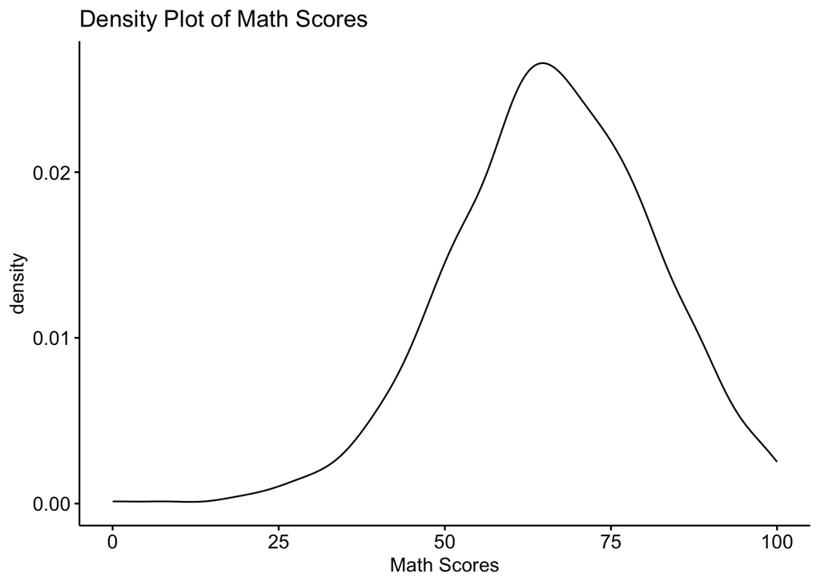

```r
ggdensity(exams$math_score,
          main = "Density Plot of Math Scores",
          xlab = "Math Scores")
```

Doesn’t look very normal

Checking qqplot of Math Scores

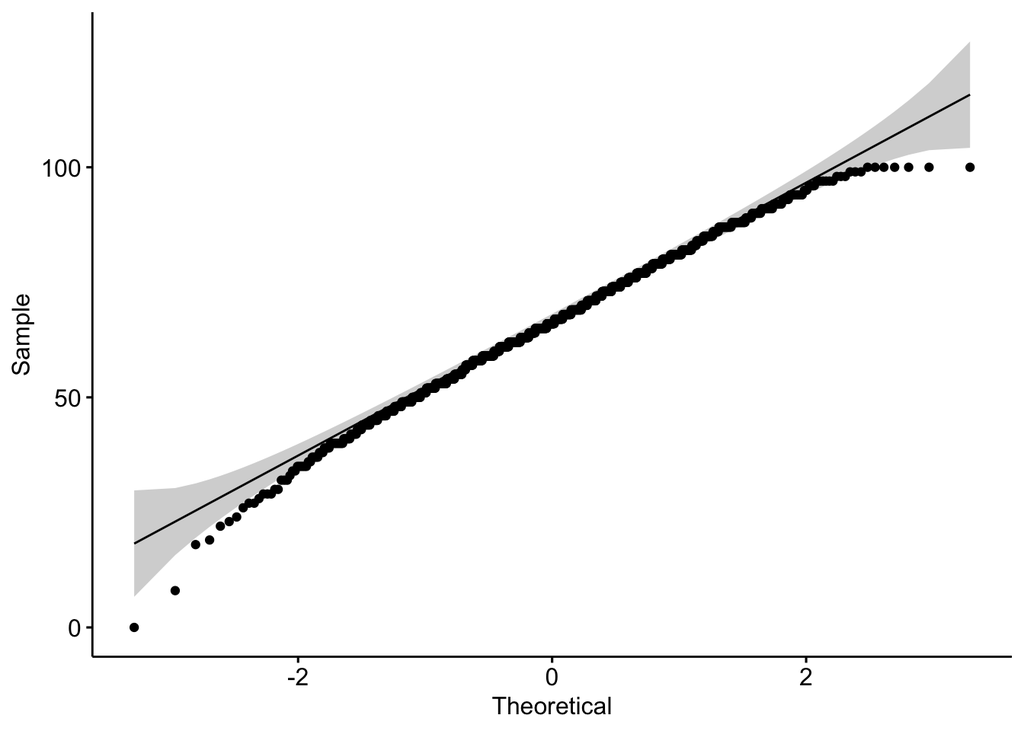

```r
ggqqplot(exams$math_score)
```

Looks possibly normal

Shapiro-Wilks test

```r
shapiro.test(exams$math_score)
```

```
##
##  Shapiro-Wilk normality test
##
## data:  exams$math_score
## W = 0.99315, p-value = 0.0001455
```

Since the p-value is below 0.05, the distribution is different from a normal distribution therefore we cannot assume the math scores are normally distributed

Let’s see reading scores

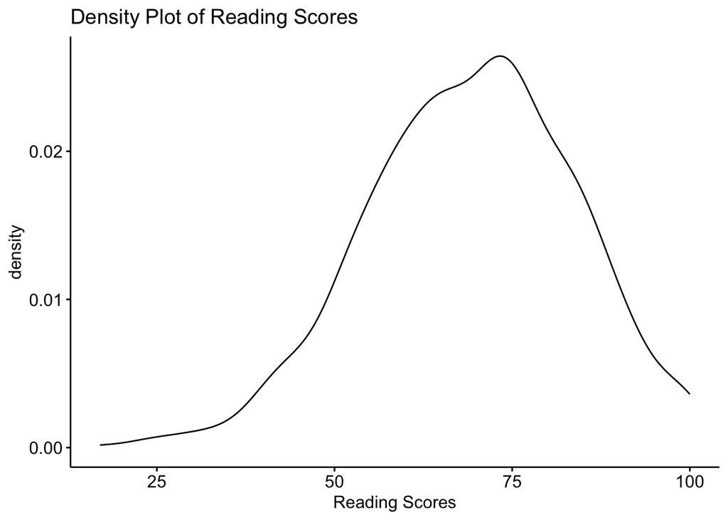

```r
ggdensity(exams$reading_score,
          main = "Density Plot of Reading Scores",
          xlab = "Reading Scores")
```

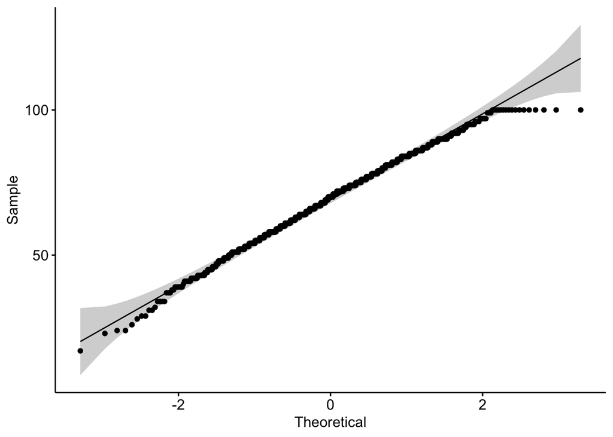

```r
ggqqplot(exams$reading_score)
```

```r
shapiro.test(exams$reading_score)
```

```
##
##  Shapiro-Wilk normality test
##
## data:  exams$reading_score
## W = 0.99292, p-value = 0.0001055
```

Conclusion: reading score is not normal

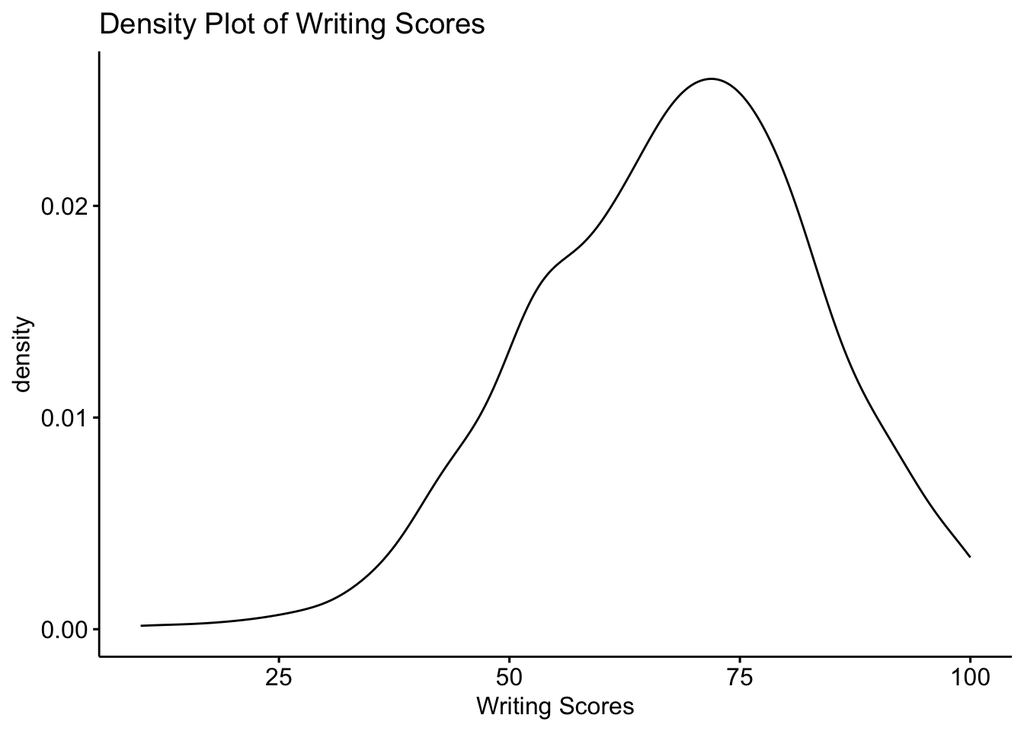

```r
ggdensity(exams$writing_score,
          main = "Density Plot of Writing Scores",
          xlab = "Writing Scores")
```

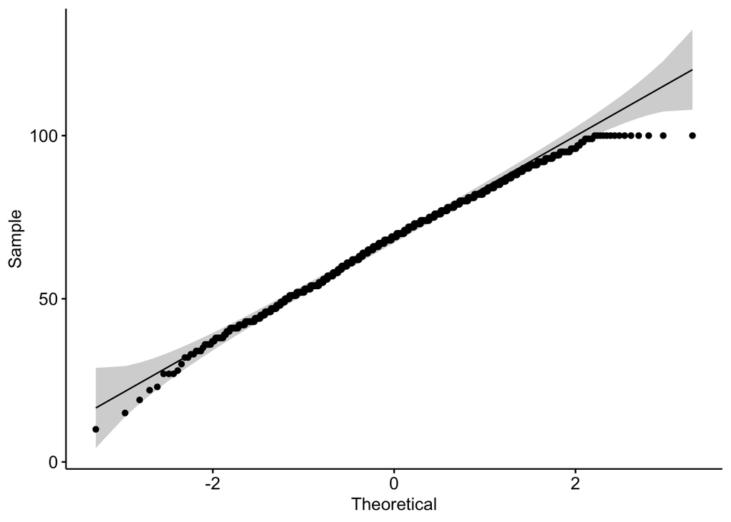

```r
ggqqplot(exams$writing_score)
```

```r
shapiro.test(exams$writing_score)
```

```
##
##  Shapiro-Wilk normality test
##
## data:  exams$writing_score
## W = 0.99196, p-value = 2.922e-05
```

Conclusion: Writing score is not normal

Linear models seeing if variables (gender, race, pariental level of education, lunch, test prep score) are strongly related to scores

model <- lm(sales ~ youtube, data = marketing) model

```r
model_math <- lm(data = exams,
            math_score ~ gender + race_ethnicity + parental_level_of_education + lunch + test_preparation_course)

summary(model_math)
```

```
##
## Call:
## lm(formula = math_score ~ gender + race_ethnicity + parental_level_of_education +
##     lunch + test_preparation_course, data = exams)
##
## Residuals:
##     Min      1Q  Median      3Q     Max
## -50.357  -8.744   0.166   9.001  30.655
##
## Coefficients:
##                                              Estimate Std. Error t value
## (Intercept)                                   57.6305     1.8721  30.784
## gender1                                        4.9953     0.8390   5.954
## race_ethnicitygroup B                          2.0408     1.6998   1.201
## race_ethnicitygroup C                          2.4700     1.5918   1.552
## race_ethnicitygroup D                          5.3410     1.6241   3.289
## race_ethnicitygroup E                         10.1347     1.8015   5.626
## parental_level_of_educationbachelor's degree   1.9661     1.5020   1.309
## parental_level_of_educationhigh school        -4.8027     1.2971  -3.703
## parental_level_of_educationmaster's degree     2.8884     1.9382   1.490
## parental_level_of_educationsome college       -0.5827     1.2470  -0.467
## parental_level_of_educationsome high school   -4.2487     1.3331  -3.187
## lunchstandard                                 10.8768     0.8727  12.463
## test_preparation_coursenone                   -5.4947     0.8756  -6.275
##                                              Pr(>|t|)
## (Intercept)                                   < 2e-16 ***
## gender1                                      3.63e-09 ***
## race_ethnicitygroup B                        0.230181
## race_ethnicitygroup C                        0.121060
## race_ethnicitygroup D                        0.001042 **
## race_ethnicitygroup E                        2.41e-08 ***
## parental_level_of_educationbachelor's degree 0.190831
## parental_level_of_educationhigh school       0.000225 ***
## parental_level_of_educationmaster's degree   0.136490
## parental_level_of_educationsome college      0.640431
## parental_level_of_educationsome high school  0.001482 **
## lunchstandard                                 < 2e-16 ***
## test_preparation_coursenone                  5.22e-10 ***
## ---
## Signif. codes:  0 '***' 0.001 '**' 0.01 '*' 0.05 '.' 0.1 ' ' 1
##
## Residual standard error: 13.17 on 987 degrees of freedom
## Multiple R-squared:  0.2548, Adjusted R-squared:  0.2457
## F-statistic: 28.12 on 12 and 987 DF,  p-value: < 2.2e-16
```

can individually go through the residual and assumption plots with plot(model_math, 1), plot(model_math,2), ….

## making plots for fun

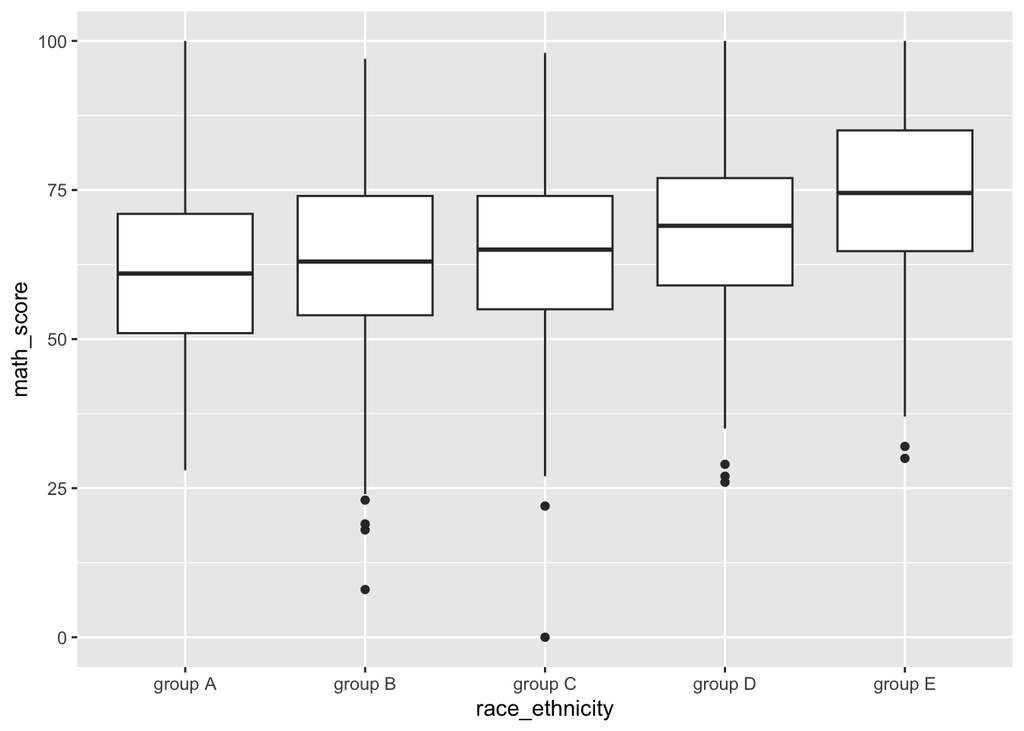

```r
ggplot(exams) + geom_boxplot(aes(y=math_score, x=race_ethnicity))
```

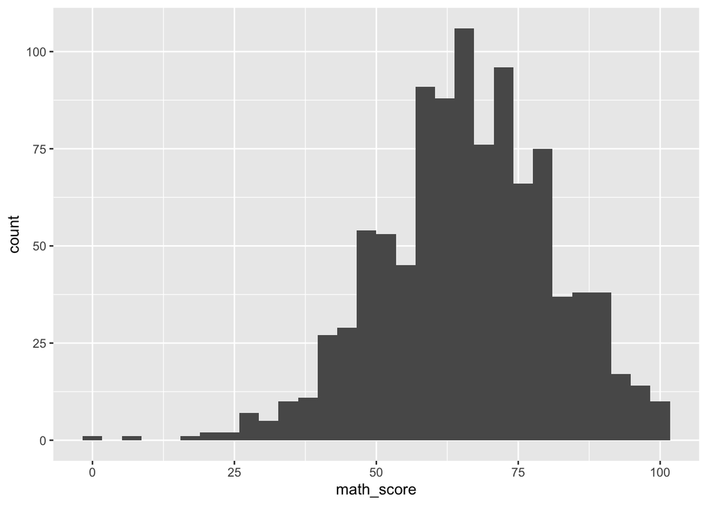

```r
ggplot(exams) + geom_histogram(aes(math_score), bins=30)
```

plot3 <- ggplot(iris, aes(Sepal.Length, Petal.Length)) + geom_point()

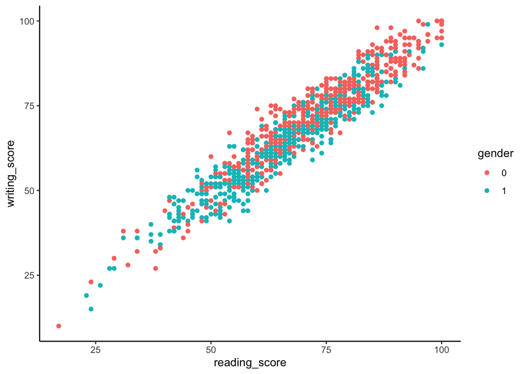

```r
ggplot(exams) + geom_point(aes(x=reading_score, y=writing_score, color=gender)) +
  theme_classic()
```